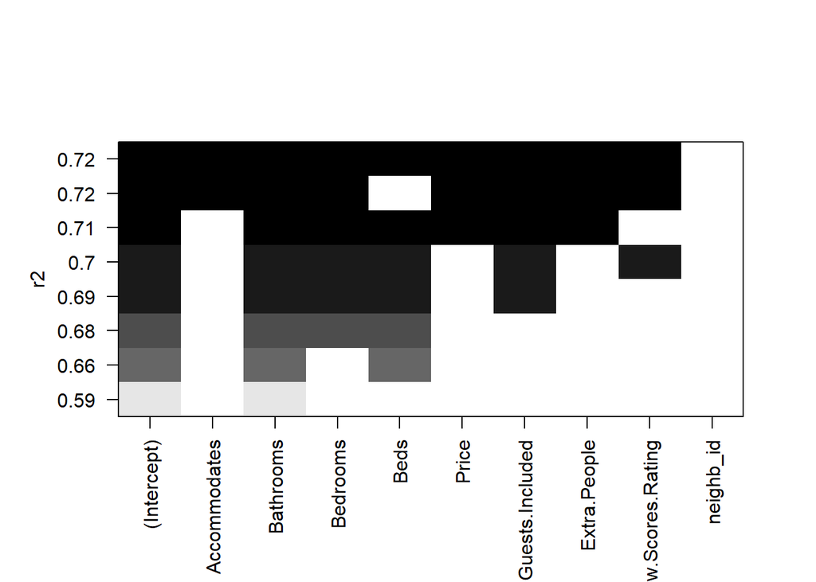

```r
plot(res, scale = "r2")
```

El siguiente modelo a probar es regresión lineal múltiple polinómica de diferentes grados

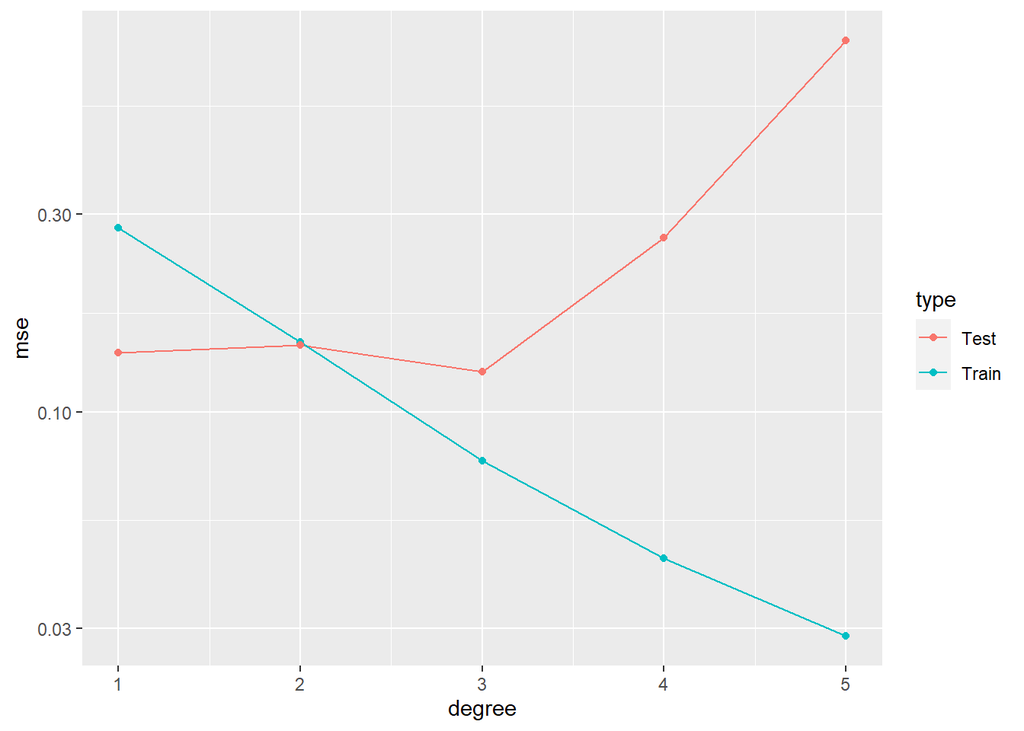

```r
calcmse<-function(y_real,y_est){
  sum((y_real-y_est)^2,na.rm = T)/length(y_real)
}

mse_train<-c()
mse_test<-c()

for( n in 1:5){

  model_lm_poly<-lm(formula =
                     Square.Meters~
                     poly(Accommodates,n)+
                     poly(Bathrooms,n)+
                     poly(Bedrooms,n)+
                     poly(Beds,n)+
                     poly(Price,n)+
                     poly(Guests.Included,n)+
                     poly(Extra.People,n)+
                     poly(Review.Scores.Rating,n)+
                     poly(neighb_id,min(n,length(unique(df_madrid.train$neighb_id))-1))
                     ,data = df_madrid.train)

  lm_poly_yp_train<-predict(model_lm_poly,df_madrid.train)
  mse_train[n]<-calcmse(df_madrid.train$Square.Meters,lm_poly_yp_train)

  lm_poly_yp_test<-predict(model_lm_poly,df_madrid.test)
  mse_test[n] <-calcmse(df_madrid.test$Square.Meters,lm_poly_yp_test)

  mse.df<-data.frame(degree=1:length(mse_train),mse=mse_train,type="Train")
  mse.df<-rbind(mse.df,data.frame(degree=1:length(mse_train),mse=mse_test,type="Test"))
}

ggplot(mse.df,aes(x=degree,y=mse,color=type))+geom_line()+geom_point()+scale_y_log10()
```

```r
n=2

model_lm_poly<-lm(formula =
                     Square.Meters~
                     poly(Accommodates,n)+
                     poly(Bathrooms,n)+
                     poly(Bedrooms,n)+
                     poly(Beds,n)+
                     poly(Price,n)+
                     poly(Guests.Included,n)+
                     poly(Extra.People,n)+
                     poly(Review.Scores.Rating,n)+
                     poly(neighb_id,min(n,length(unique(df_madrid.train$neighb_id))-1))
                     ,data = df_madrid.train)

lm_yp_degree_2_train<-predict(model_lm_poly,df_madrid.train)
caret::postResample(pred=lm_yp_degree_2_train, obs=df_madrid.train$Square.Meters)
```

```
##      RMSE  Rsquared       MAE
## 0.3838053 0.8514014 0.2657161
```

```r
lm_yp_degree_2_test<-predict(model_lm_poly,df_madrid.test)
caret::postResample(pred=lm_yp_degree_2_test, obs=df_madrid.test$Square.Meters)
```

```
##      RMSE  Rsquared       MAE
## 0.3812187 0.6609850 0.3125708
```

El siguiente modelo a probar será un modelo lineal múltiple con regularización y validación cruzada.

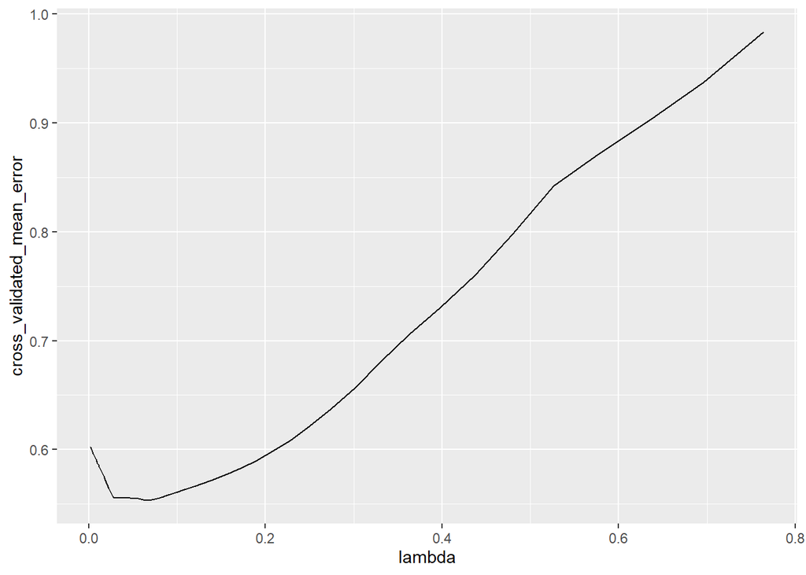

```r
cv<-glmnetUtils::cv.glmnet(formula=
                           Square.Meters~
                           Accommodates+
                           Bathrooms+
                           Bedrooms+
                           Beds+
                           Price+
                           Guests.Included+
                           Extra.People+
                           Review.Scores.Rating+
                           neighb_id,
                           data=df_madrid.train,
                           alpha=1,
                           nfold= 10,
                           type.measure="mse")

ggplot(data.frame(lambda=cv$lambda,cross_validated_mean_error=cv$cvm),
       aes(x=lambda,y=cross_validated_mean_error))+geom_line()
```

```r
paste0("El valor lambda con el menor error es:",cv$lambda.min)
```

```
## [1] "El valor lambda con el menor error es:0.0680047936287513"
```

```r
paste0("El valor lambda más alto que se encuentra a una distancia 1sd es:",cv$lambda.1se)
```

```
## [1] "El valor lambda más alto que se encuentra a una distancia 1sd es:0.479760375232059"
```

```r
paste0("El R^2 estimado es", cv$glmnet.fit$dev.ratio[which(cv$glmnet.fit$lambda == cv$lambda.1se)])
```

```
## [1] "El R^2 estimado es0.386997204947443"
```

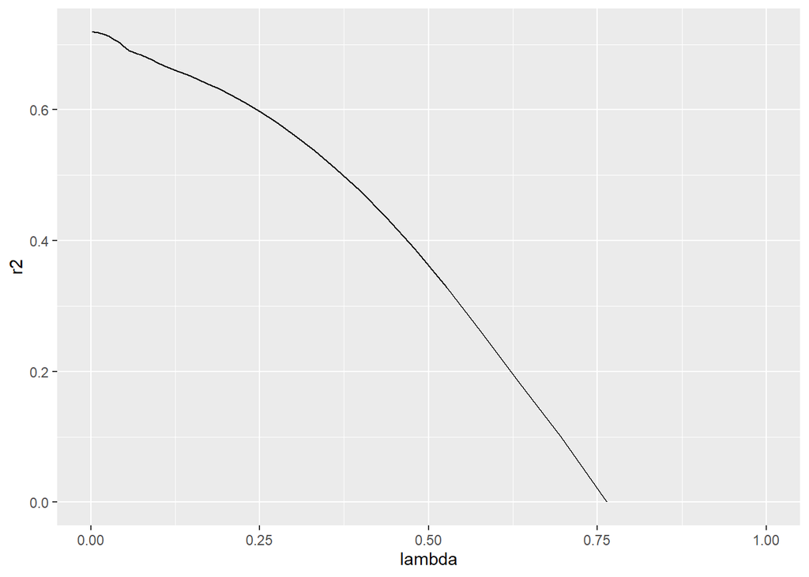

```r
ggplot(data.frame(lambda=cv$lambda,r2=cv$glmnet.fit$dev.ratio),
       aes(x=lambda,y=r2))+geom_line()+xlim(0,1)
```

Aplicando regularización nos da un Rsquared más bajo.

Por último vamos a usar un modelo glm

```r
model_glm<- glm( Square.Meters~
                        Accommodates+
                        Bathrooms+
                        Bedrooms+
                        Beds+
                        Price+
                        Guests.Included+
                        Extra.People+
                        Review.Scores.Rating+
                        neighb_id,
                        family = gaussian,
                        data = df_madrid.train)
summary(model_glm)
```

```
##
## Call:
## glm(formula = Square.Meters ~ Accommodates + Bathrooms + Bedrooms +
##     Beds + Price + Guests.Included + Extra.People + Review.Scores.Rating +
##     neighb_id, family = gaussian, data = df_madrid.train)
##
## Deviance Residuals:
##      Min        1Q    Median        3Q       Max
## -2.04771  -0.19020  -0.01979   0.22845   2.99964
##
## Coefficients:
##                        Estimate Std. Error t value Pr(>|t|)
## (Intercept)          -7.039e-17  5.153e-02   0.000  1.00000
## Accommodates          1.438e-01  1.347e-01   1.067  0.28829
## Bathrooms             4.778e-01  7.904e-02   6.045 2.31e-08 ***
## Bedrooms              1.993e-01  1.002e-01   1.990  0.04918 *
## Beds                  1.251e-01  1.205e-01   1.038  0.30149
## Price                 1.143e-01  6.743e-02   1.695  0.09302 .
## Guests.Included      -1.990e-01  7.338e-02  -2.712  0.00781 **
## Extra.People          9.522e-02  6.248e-02   1.524  0.13047
## Review.Scores.Rating  8.800e-02  5.269e-02   1.670  0.09788 .
## neighb_id             6.953e-03  5.723e-02   0.121  0.90354
## ---
## Signif. codes:  0 '***' 0.001 '**' 0.01 '*' 0.05 '.' 0.1 ' ' 1
##
## (Dispersion parameter for gaussian family taken to be 0.3053607)
##
##     Null deviance: 114.000  on 114  degrees of freedom
## Residual deviance:  32.063  on 105  degrees of freedom
## AIC: 201.47
##
## Number of Fisher Scoring iterations: 2
```

```r
model_glm_reduce <- update(model_glm, . ~ . - Square.Meters)
summary(model_glm_reduce)
```

```
##
## Call:
## glm(formula = Square.Meters ~ Accommodates + Bathrooms + Bedrooms +
##     Beds + Price + Guests.Included + Extra.People + Review.Scores.Rating +
##     neighb_id, family = gaussian, data = df_madrid.train)
##
## Deviance Residuals:
##      Min        1Q    Median        3Q       Max
## -2.04771  -0.19020  -0.01979   0.22845   2.99964
##
## Coefficients:
##                        Estimate Std. Error t value Pr(>|t|)
## (Intercept)          -7.039e-17  5.153e-02   0.000  1.00000
## Accommodates          1.438e-01  1.347e-01   1.067  0.28829
## Bathrooms             4.778e-01  7.904e-02   6.045 2.31e-08 ***
## Bedrooms              1.993e-01  1.002e-01   1.990  0.04918 *
## Beds                  1.251e-01  1.205e-01   1.038  0.30149
## Price                 1.143e-01  6.743e-02   1.695  0.09302 .
## Guests.Included      -1.990e-01  7.338e-02  -2.712  0.00781 **
## Extra.People          9.522e-02  6.248e-02   1.524  0.13047
## Review.Scores.Rating  8.800e-02  5.269e-02   1.670  0.09788 .
## neighb_id             6.953e-03  5.723e-02   0.121  0.90354
## ---
## Signif. codes:  0 '***' 0.001 '**' 0.01 '*' 0.05 '.' 0.1 ' ' 1
##
## (Dispersion parameter for gaussian family taken to be 0.3053607)
##
##     Null deviance: 114.000  on 114  degrees of freedom
## Residual deviance:  32.063  on 105  degrees of freedom
## AIC: 201.47
##
## Number of Fisher Scoring iterations: 2
```

```r
glm_reduce_train <-predict(model_glm_reduce,df_madrid.train)
caret::postResample(pred=glm_reduce_train, obs=df_madrid.train$Square.Meters)
```

```
##      RMSE  Rsquared       MAE
## 0.5280224 0.7187467 0.3315189
```

```r
glm_reduce_test <-predict(model_glm_reduce,df_madrid.test)
caret::postResample(pred=glm_reduce_test, obs=df_madrid.test$Square.Meters)
```

```
##      RMSE  Rsquared       MAE
## 0.3731866 0.6889228 0.2835760
```

El modelo glm mejora los resultados de la regresión lineal múltple con grados .

Por último usaremos un modelo gam con una familia gausiana

```r
library(mgcv)
model_gam<-mgcv::gam(Square.Meters~
               Accommodates+
               Bathrooms+
               Bedrooms+
               Beds+
               Price+
               Guests.Included+
               Extra.People+
               Review.Scores.Rating+
               neighb_id
               ,family = gaussian()
               ,data = df_madrid.train)
```

```r
gam_train<-predict(model_gam,df_madrid.train)
caret::postResample(pred=gam_train, obs=df_madrid.train$Square.Meters)
```

```
##      RMSE  Rsquared       MAE
## 0.5280224 0.7187467 0.3315189
```

```r
gam_test<-predict(model_gam,df_madrid.test)
caret::postResample(pred=gam_test, obs=df_madrid.test$Square.Meters)
```

```
##      RMSE  Rsquared       MAE
## 0.3731866 0.6889228 0.2835760
```

Este modelo nos iguala el Rsquared para test con respecto a glm.

Por lo cual nos quedamos el modelo que mejor resultado de Rsquared nos ha dado en el test y gam

14. Mirad el histograma de los residuos sobre el conjunto de test para evaluar la calidad de vuestro modelo

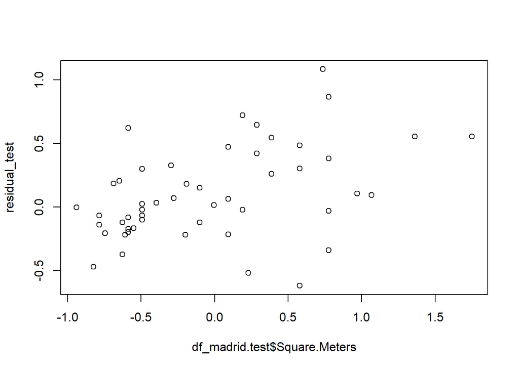

```r
residual_test <- df_madrid.test$Square.Meters-gam_test
plot(df_madrid.test$Square.Meters,residual_test)
```

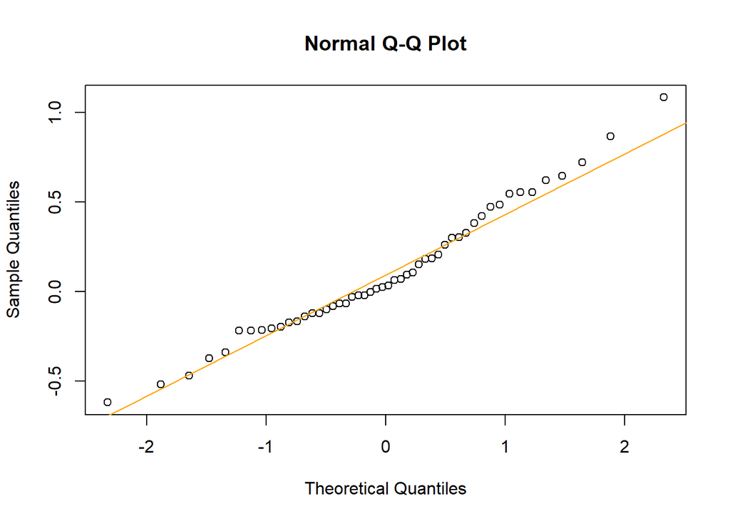

```r
qqnorm(residual_test)
qqline(residual_test,col="orange")
```

Las gráficas nos muestra que los residuos tienes homoestaicidad teniendo en cuenta que no hay muchos datos para poder entrenar los modelos.

La gráfica Q-Q está alineada.

```r
predict_squaremeters <-function(modelo,df_predict){
    df_predict_scale <- predict(preProcValues,df_predict)
    ejemplo_predict<-predict(modelo,df_predict_scale)
    return(ejemplo_predict * preProcValues$std["Price"] + preProcValues$mean["Price"] )
}
```

```r
#Introducir los valores necesarios
Accommodates = 5
Bathrooms = 1
Bedrooms  = 4
Beds      = 2
Price     = 50
Guests.Included = 0
Extra.People = 0
Review.Scores.Rating = 80
Latitude=40.42119
Longitude = -3.697971
Square.Meters = 0 #No se usará para el modelo. Es necesaria para el Preproccess
neighb_id = myclust$cluster["Sol"]

entrada_predict <- data.frame(Accommodates,
                              Bathrooms,
                              Bedrooms,
                              Beds,
                              Price,
                              Guests.Included,
                              Extra.People,
                              Review.Scores.Rating,
                              Square.Meters,
                              Latitude,
                              Longitude,
                              neighb_id)

prediccion<-predict_squaremeters(model_gam,entrada_predict)
cat("Paras los datos introducidos la preddición es de ",paste(round(prediccion,2))," metros cuadrados\n")
```

```
## Paras los datos introducidos la preddición es de  118.26  metros cuadrados
```

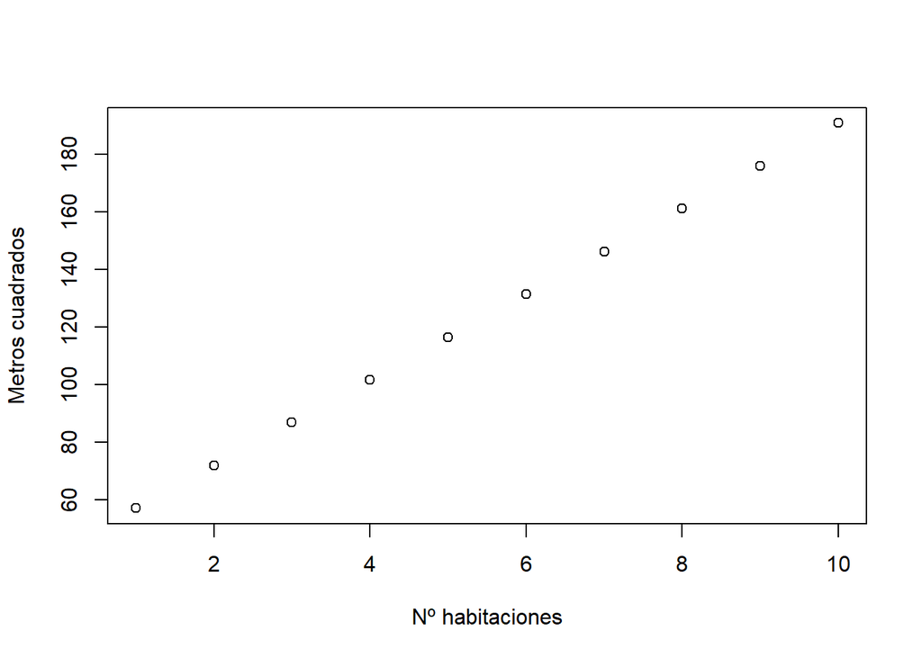

```r
habitacion_metroscuadrados <- c()

for(i in 1:10){
  Accommodates = 5
  Bathrooms = 1
  Bedrooms  = i
  Beds      = 2
  Price     = 50
  Guests.Included = 0
  Extra.People = 0
  Review.Scores.Rating = 80
  Square.Meters = 0
  Latitude=40.42119
  Longitude = -3.697971
  neighb_id = myclust$cluster["Sol"]

  entrada_predict <- data.frame(Accommodates,
                                Bathrooms,
                                Bedrooms,
                                Beds,
                                Price,
                                Guests.Included,
                                Extra.People,
                                Review.Scores.Rating,
                                Square.Meters,
                                Latitude,
                                Longitude,
                                neighb_id)

  habitacion_metroscuadrados[i] <-predict_squaremeters(model_lm,entrada_predict)
}

plot(habitacion_metroscuadrados,xlab="Nº habitaciones",ylab="Metros cuadrados",xlim=c(1,10))
```